# Network Analysis — Streckenveränderungen 2023–2025

Das Zürcher Tramnetz ist kein statisches Objekt. Im Analysezeitraum 2023–2025 gab es mit dem Fahrplanwechsel Dezember 2023 den größten Netzausbau in der Geschichte der VBZ. Dieses Notebook untersucht **was** sich verändert hat, **wo** und **wann** — und was das für die Pünktlichkeit bedeutet.

**Zentrale Fragen:**

1. Wo haben sich die meisten Änderungen abgespielt? — Haltestellen und Stadtteile
2. Wieviel hat sich verändert? — Quantifizierung pro Linie und gesamt
3. Wann fanden die Änderungen statt? — Zeitachse
4. Hat sich die Lage nach dem Ausbau verbessert oder verschlechtert? — Einlaufzeit neuer Abschnitte
5. Welche Knotenpunkte sind kritische Hotspots? — Kaskaden und Linienüberschneidungen
6. Welche Stadtteile profitieren? — Versorgungsqualität

**Rückschluss für alle weiteren Analysen:** → am Ende dieses Notebooks

## Setup

```python
from zh_tram_flow.notebook import *
import zh_tram_flow.analytics.network as an

TRAIN, TEST, lf, lf_all, lf_delay, lf_clean = setup_analysis("03_analysis_2-network")

# lf_all   — train + test features combined (all years)
# lf_delay — lf_all filtered: canceled == False
# lf_clean — analysis-ready: canceled=False · stop_sequence>1 · no Linie E/L50/L51
#             departure_delay / delay_delta masked to NaN for Nov 14–Dec 23 2025
#             (is_anomal flag added for transparency)
%load_ext autoreload
%autoreload 2
```

```
✓  wgnd theme activated (matplotlib · seaborn)
```

```
2026-06-11 11:22:54  INFO      project  03_analysis_2-network started
```

```
The autoreload extension is already loaded. To reload it, use:
  %reload_ext autoreload
```

```python
log("Lade GTFS j23 / j24 / j25 ...")
gtfs, all_lines = an.load_gtfs(PATHS["root"])
success(f"{len(all_lines)} Linien geladen: {all_lines}")

changes = an.build_changes_matrix(gtfs, all_lines)
success(f"Änderungsmatrix: {len(changes)} Linien")
show_df(changes[["line","n_j23","n_j24","n_j25","added_j24","removed_j24","added_j25","removed_j25"]].set_index("line"))
```

```
Lade GTFS j23 / j24 / j25 ...
✓  18 Linien geladen: ['2', '3', '4', '5', '6', '7', '8', '9', '10', '11', '12', '13', '14', '15', '17', '18', '19', 'E']
✓  Änderungsmatrix: 18 Linien
```

| line | n_j23 | n_j24 | n_j25 | added_j24 | removed_j24 | added_j25 | removed_j25 |
| --- | --- | --- | --- | --- | --- | --- | --- |
| 2 | 31 | 21 | 31 | 1 | 11 | 10 | 0 |
| 3 | 21 | 21 | 21 | 2 | 2 | 0 | 0 |
| 4 | 26 | 26 | 26 | 1 | 1 | 1 | 1 |
| 5 | 9 | 9 | 14 | 0 | 0 | 6 | 1 |
| 6 | 24 | 16 | 16 | 6 | 14 | 0 | 0 |
| 7 | 31 | 31 | 31 | 2 | 2 | 0 | 0 |
| 8 | 23 | 24 | 24 | 11 | 10 | 1 | 1 |
| 9 | 24 | 32 | 32 | 13 | 5 | 1 | 1 |
| 10 | 27 | 27 | 27 | 0 | 0 | 0 | 0 |
| 11 | 20 | 33 | 34 | 16 | 3 | 10 | 9 |
| 12 | 18 | 18 | 18 | 0 | 0 | 0 | 0 |
| 13 | 11 | 30 | 30 | 22 | 3 | 0 | 0 |
| 14 | 27 | 27 | 27 | 0 | 0 | 0 | 0 |
| 15 | 13 | 13 | 13 | 1 | 1 | 1 | 1 |
| 17 | 17 | 17 | 17 | 0 | 0 | 0 | 0 |
| 18 | 0 | 16 | 0 | 16 | 0 | 0 | 16 |
| 19 | 12 | 12 | 12 | 1 | 1 | 0 | 0 |
| E | 0 | 7 | 7 | 7 | 0 | 0 | 0 |

## Überblick — Das Netz im Wandel

### Interaktive Karte

```python
an.plot_network_changes_map(changes)
```

[output not shown]

## Wo? — Räumliche Verteilung der Änderungen

```
───  NEUE HALTESTELLEN NACH STADTKREIS  ──────────────────────
```

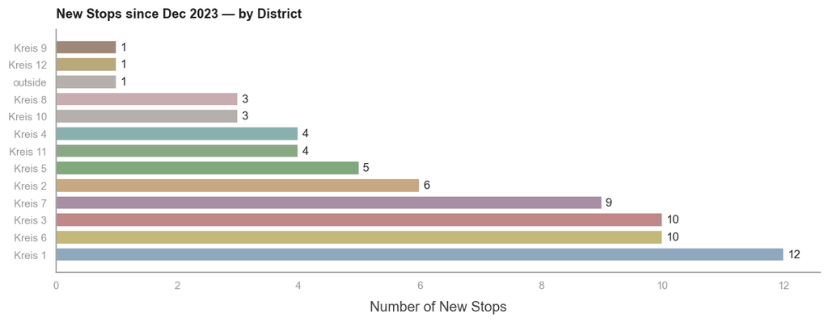

|  | District | Neue Halte (ab j24) |
| --- | --- | --- |
| 8 | Kreis 1 | 12 |
| 6 | Kreis 3 | 10 |
| 1 | Kreis 6 | 10 |
| 7 | Kreis 7 | 9 |
| 2 | Kreis 2 | 6 |
| 12 | Kreis 5 | 5 |
| 5 | Kreis 4 | 4 |
| 9 | Kreis 11 | 4 |
| 10 | Kreis 8 | 3 |
| 11 | Kreis 10 | 3 |
| 4 | Kreis 12 | 1 |
| 0 | outside | 1 |
| 3 | Kreis 9 | 1 |

```
Netto-Änderungen pro Linie (j23→j24 und j24→j25)
```

| Line | Halte j23 | Halte j24 | Halte j25 | +j24 | -j24 | +j25 | -j25 | Δ j23→j24 | Δ j24→j25 |
| --- | --- | --- | --- | --- | --- | --- | --- | --- | --- |
| 2 | 31 | 21 | 31 | 1 | 11 | 10 | 0 | -10 | 10 |
| 3 | 21 | 21 | 21 | 2 | 2 | 0 | 0 | 0 | 0 |
| 4 | 26 | 26 | 26 | 1 | 1 | 1 | 1 | 0 | 0 |
| 5 | 9 | 9 | 14 | 0 | 0 | 6 | 1 | 0 | 5 |
| 6 | 24 | 16 | 16 | 6 | 14 | 0 | 0 | -8 | 0 |
| 7 | 31 | 31 | 31 | 2 | 2 | 0 | 0 | 0 | 0 |
| 8 | 23 | 24 | 24 | 11 | 10 | 1 | 1 | 1 | 0 |
| 9 | 24 | 32 | 32 | 13 | 5 | 1 | 1 | 8 | 0 |
| 10 | 27 | 27 | 27 | 0 | 0 | 0 | 0 | 0 | 0 |
| 11 | 20 | 33 | 34 | 16 | 3 | 10 | 9 | 13 | 1 |
| 12 | 18 | 18 | 18 | 0 | 0 | 0 | 0 | 0 | 0 |
| 13 | 11 | 30 | 30 | 22 | 3 | 0 | 0 | 19 | 0 |
| 14 | 27 | 27 | 27 | 0 | 0 | 0 | 0 | 0 | 0 |
| 15 | 13 | 13 | 13 | 1 | 1 | 1 | 1 | 0 | 0 |
| 17 | 17 | 17 | 17 | 0 | 0 | 0 | 0 | 0 | 0 |
| 18 | 0 | 16 | 0 | 16 | 0 | 0 | 16 | 16 | -16 |
| 19 | 12 | 12 | 12 | 1 | 1 | 0 | 0 | 0 | 0 |
| E | 0 | 7 | 7 | 7 | 0 | 0 | 0 | 7 | 0 |

```python
section_header("Neue Haltestellen nach Stadtkreis")
an.plot_new_stops_by_district(changes, lf_all, cfg)
show_df(an.table_new_stops_by_district(changes, lf_all))

log("Netto-Änderungen pro Linie (j23→j24 und j24→j25)")
show_df(an.table_network_netto_changes(changes))
```

**Beobachtung:** Das Balkendiagramm zeigt, dass die meisten neuen GTFS-Haltestellen in den Innenstadt-Kreisen erscheinen — Kreis 1 mit 12 neuen Haltestellen führt. Das ist zunächst überraschend, lässt sich aber nach Prüfung der konkreten Haltestellen-Namen erklären.

**Top-Kreise nach neuen GTFS-Haltestellen (ab Dez 2023):**

[output not shown]

**Was steckt dahinter — zwei verschiedene Ursachen:**

1. **GTFS-Artefakt (K1, K6):** Die meisten "neuen" Halte in Kreis 1 sind Stammhaltestellen, die seit Jahrzehnten bestehen — Paradeplatz, Bahnhofstrasse/HB, Rennweg, Stockerstrasse, Tunnelstrasse. Sie erscheinen als "neu", weil L6, L8, L9, L13 ab j24 andere repräsentative Trip-Shapes im GTFS nutzen, die durch diese Innenstadt-Achse führen. **Keine neue Infrastruktur.**
2. **Echte Streckenerweiterungen (K3, K8):**
   - **L13 → Sihlcity/Süd (K3):** Albisgütli, Laubegg, Eschergutweg, Waidfussweg, Sihlcity Nord, Uetlihof — echte neue Endabschnitte im Süden
   - **L11 → Rehalp/Zürichberg (K8):** Balgrist, Rehalp, Burgwies, Friedhof Enzenbühl, Hedwigsteig, Hegibachplatz — Verlängerung Richtung Zürichberg

## Wieviel? — Quantifizierung der Änderungen

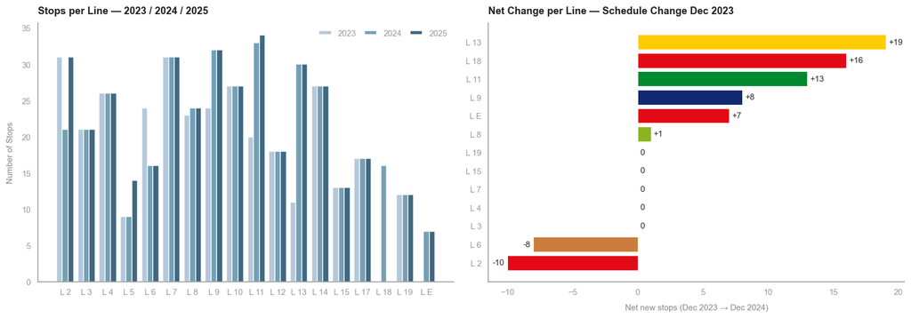

| Line | Halte j23 | Halte j24 | Halte j25 | +j24 | -j24 | +j25 | -j25 | Δ j23→j24 | Δ j24→j25 |
| --- | --- | --- | --- | --- | --- | --- | --- | --- | --- |
| 2 | 31 | 21 | 31 | 1 | 11 | 10 | 0 | -10 | 10 |
| 3 | 21 | 21 | 21 | 2 | 2 | 0 | 0 | 0 | 0 |
| 4 | 26 | 26 | 26 | 1 | 1 | 1 | 1 | 0 | 0 |
| 5 | 9 | 9 | 14 | 0 | 0 | 6 | 1 | 0 | 5 |
| 6 | 24 | 16 | 16 | 6 | 14 | 0 | 0 | -8 | 0 |
| 7 | 31 | 31 | 31 | 2 | 2 | 0 | 0 | 0 | 0 |
| 8 | 23 | 24 | 24 | 11 | 10 | 1 | 1 | 1 | 0 |
| 9 | 24 | 32 | 32 | 13 | 5 | 1 | 1 | 8 | 0 |
| 10 | 27 | 27 | 27 | 0 | 0 | 0 | 0 | 0 | 0 |
| 11 | 20 | 33 | 34 | 16 | 3 | 10 | 9 | 13 | 1 |
| 12 | 18 | 18 | 18 | 0 | 0 | 0 | 0 | 0 | 0 |
| 13 | 11 | 30 | 30 | 22 | 3 | 0 | 0 | 19 | 0 |
| 14 | 27 | 27 | 27 | 0 | 0 | 0 | 0 | 0 | 0 |
| 15 | 13 | 13 | 13 | 1 | 1 | 1 | 1 | 0 | 0 |
| 17 | 17 | 17 | 17 | 0 | 0 | 0 | 0 | 0 | 0 |
| 18 | 0 | 16 | 0 | 16 | 0 | 0 | 16 | 16 | -16 |
| 19 | 12 | 12 | 12 | 1 | 1 | 0 | 0 | 0 | 0 |
| E | 0 | 7 | 7 | 7 | 0 | 0 | 0 | 7 | 0 |

```python
an.plot_network_stop_count_by_line(changes, cfg)

show_df(an.table_network_netto_changes(changes))
```

**Beobachtung:** Das Quantifizierungs-Chart und die Tabelle liefern klare Zahlen zum Ausmass der GTFS-Änderungen.

**Netto-Änderungen j23 → j24 (die grossen Bewegungen):**

| Linie | j23 | j24 | j25 | Δ j23→j24 | Anmerkung |
| --- | --- | --- | --- | --- | --- |
| **L13** | 11 | 30 | 30 | **+19** | Grösste Änderung (+173%) |
| **L11** | 20 | 33 | 34 | **+13** | +16 hinzu, -3 entfernt |
| **L9** | 24 | 32 | 32 | **+8** | +13 hinzu, -5 entfernt |
| L18 | 0 | 16 | 0 | +16 | Temporäre Linie — nur 2024 aktiv |
| **L6** | 24 | 16 | 16 | **−8** | Netto 8 Halte entfernt |

**Anomalie L2:** j23=31 Halte → j24=21 (−10) → j25=31 (+10 zurück). Die Haltestellen-Zahl schwankt stark zwischen den Jahren, obwohl L2 als "stabil" gilt. Wahrscheinlich eine GTFS-Routing-Variante (andere Wendeäste oder Kursführung je Fahrplan), keine reale Streckenkürzung und Rückkehr.

**Stabil über alle Jahre:** L10, L12, L14, L17 (identische Haltestellen-Zahl in j23/j24/j25) — echte Referenzlinien für jahresübergreifende Vergleiche.

## Wann? — Zeitachse der Änderungen

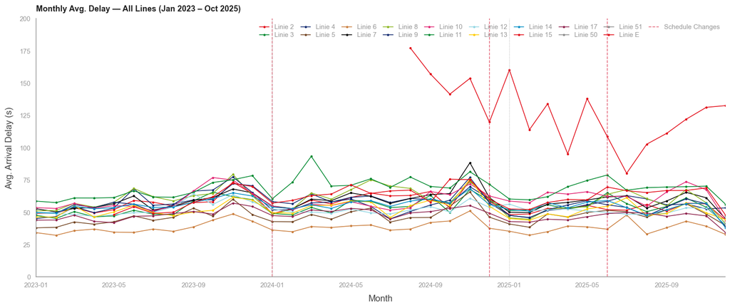

|  | Line | Typ | nach Wechsel (2024–2025) | vor Wechsel (2023) | Δ (s) |
| --- | --- | --- | --- | --- | --- |
| 1 | 11 | ✦ verändert (j24) | 70.40 | 65.10 | 5.30 |
| 5 | 15 | stabil | 63.10 | 57.90 | 5.20 |
| 10 | 5 | stabil | 48.00 | 45.60 | 2.40 |
| 14 | 7 | stabil | 59.60 | 57.40 | 2.20 |
| 8 | 3 | stabil | 54.70 | 52.60 | 2.10 |
| 3 | 13 | ✦ verändert (j24) | 53.00 | 51.60 | 1.40 |
| 13 | 6 | stabil | 38.60 | 37.90 | 0.70 |
| 0 | 10 | stabil | 60.10 | 59.50 | 0.60 |
| 6 | 17 | stabil | 47.90 | 47.80 | 0.10 |
| 9 | 4 | stabil | 57.40 | 57.50 | -0.10 |
| 7 | 2 | stabil | 56.20 | 56.50 | -0.30 |
| 4 | 14 | stabil | 55.10 | 55.80 | -0.70 |
| 15 | 8 | stabil | 59.20 | 60.80 | -1.60 |
| 2 | 12 | stabil | 51.20 | 53.10 | -1.90 |
| 16 | 9 | ✦ verändert (j24) | 54.30 | 58.70 | -4.40 |
| 11 | 50 | stabil | 46.60 | nan | nan |
| 12 | 51 | stabil | 41.40 | nan | nan |
| 17 | E | stabil | 128.10 | nan | nan |

```python
an.plot_monthly_delay_all_lines(lf_all, cfg, ylim=(0, 200))

show_df(an.table_delay_before_after_switch(lf_all))
```

**Legende Vertikale Linien:**

[output not shown]

**Beobachtung:** Kein erkennbarer Knick oder Sprung bei Jan 2024 (Fahrplanwechsel). Die Zeitreihen für alle Linien verlaufen kontinuierlich über den Wechsel hinweg.

**Veränderte vs. stabile Linien — Δ vor/nach Fahrplanwechsel:**

[output not shown]

**Kernbefund:** Die veränderten Linien zeigen keine einheitliche Richtung — L11 stieg um +5.3s, L9 verbesserte sich um −4.4s. Noch deutlicher: L15 (stabil, keine GTFS-Änderung) erhöhte sich um +5.2s — praktisch identisch mit L11 (+5.3s). Da stabile und veränderte Linien die gleiche Bandbreite an Veränderungen zeigen, liegt die Quelle der Variation nicht im Netzwechsel selbst, sondern in externen Faktoren (saisonale Muster, Fahrgastzuwachs, Wetter).

**Starkes Finding:** Die VBZ hat den grössten Fahrplanwechsel in der Netzgeschichte ohne erkennbare Verspätungs-Disruption durchgeführt. Der Netzwechsel ist im Delay-Signal nicht sichtbar.

## Einlaufzeit — Performen neue Abschnitte anders?

```
───  EINLAUFZEIT — NEUE VS. BESTEHENDE HALTESTELLEN  ─────────
Einlaufzeit Diagramme
```

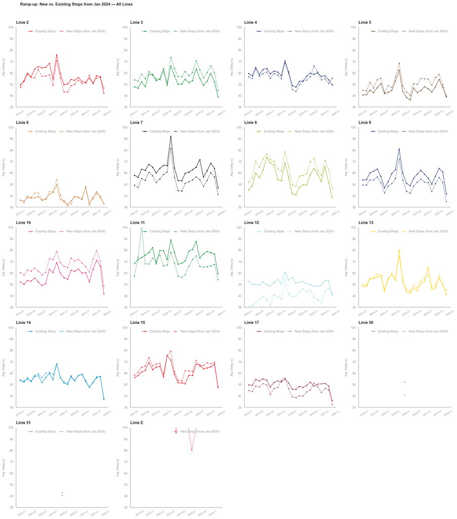

| Line | Bestehende Halte (s) | Neue Halte (s) | Δ neu−best. (s) |
| --- | --- | --- | --- |
| 11 | 75.70 | 68.50 | -7.20 |
| 10 | 57.80 | 66.50 | 8.70 |
| 15 | 60.80 | 64.10 | 3.30 |
| 8 | 55.30 | 63.40 | 8.10 |
| 3 | 53.50 | 58.80 | 5.30 |
| 4 | 58.20 | 56.40 | -1.80 |
| 14 | 54.50 | 55.70 | 1.20 |
| 7 | 62.80 | 54.30 | -8.50 |
| 2 | 56.80 | 53.50 | -3.30 |
| 13 | 52.70 | 53.20 | 0.50 |
| 5 | 45.60 | 50.70 | 5.10 |
| 9 | 57.40 | 50.70 | -6.70 |
| 17 | 49.90 | 45.40 | -4.50 |
| 50 | 52.10 | 40.70 | -11.40 |
| 51 | 42.80 | 40.50 | -2.30 |
| 12 | 51.30 | 39.70 | -11.60 |
| 6 | 38.50 | 39.10 | 0.60 |

```python
section_header("Einlaufzeit — neue vs. bestehende Haltestellen")

log("Einlaufzeit Diagramme")
an.plot_ramp_up(changes, lf_all, cfg, ylim=(30, 100))


show_df(an.table_ramp_up(changes, lf_all))
```

**Beobachtung:** Die Einlaufzeit-Charts zeigen kein einheitliches Muster — das Ergebnis ist linienabhängig und erklärt sich aus der Lage der Haltestellen.

**Neue vs. bestehende Haltestellen — Ø Delay ab Jan 2024:**

[output not shown]

**Warum performen die "neuen" L11/L9-Halte besser?**  
L11 und L9 haben im GTFS vor allem Innenstadthalte als "neu" — Paradeplatz, Bellevue, Bürkliplatz, Bahnhof Stadelhofen. Das sind gut ausgebaute, häufig angefahrene Knotenpunkte mit stabiler Infrastruktur. Dass sie besser performen als die "bestehenden" Halte (die eher die Endabschnitte im problematischen K11/K12 abdecken) bestätigt den Befund aus der Stadtkreis-Analyse: Das Randlagen-Problem existiert unabhängig vom Netzwechsel.

> **Fazit:** Kein klassischer Einlauf-Effekt nachweisbar. Die Unterschiede sind lagebezogen, nicht zeitbezogen.

## Hotspots & Kaskaden — Kritische Knotenpunkte

```
───  HOTSPOTS & KASKADEN  ────────────────────────────────────
Hotspot Diagramme
```

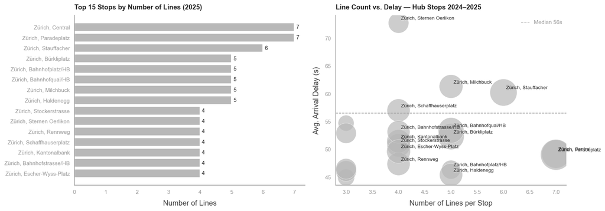

```
Hotspot Tabelle
```

|  | Stop | Linien | Linienliste | Avg. Delay (s) | Beobachtungen |
| --- | --- | --- | --- | --- | --- |
| 0 | Zürich, Central | 7 | 3, 4, 6, 7, 10, 15, 19 | 49.10 | 1081588 |
| 1 | Zürich, Paradeplatz | 7 | 2, 6, 7, 8, 9, 11, 13 | 49.00 | 1270955 |
| 2 | Zürich, Stauffacher | 6 | 2, 3, 8, 9, 14, 19 | 60.20 | 986075 |
| 3 | Zürich, Bürkliplatz | 5 | 2, 5, 8, 9, 11 | 52.30 | 917620 |
| 4 | Zürich, Bahnhofplatz/HB | 5 | 3, 10, 14, 17, 19 | 46.30 | 474041 |
| 5 | Zürich, Bahnhofquai/HB | 5 | 4, 11, 13, 14, 17 | 53.40 | 880893 |
| 6 | Zürich, Milchbuck | 5 | 7, 9, 10, 14, E | 61.30 | 747434 |
| 7 | Zürich, Haldenegg | 5 | 6, 7, 10, 15, 19 | 45.40 | 711757 |
| 8 | Zürich, Stockerstrasse | 4 | 6, 7, 8, 13 | 50.70 | 725527 |
| 9 | Zürich, Sternen Oerlikon | 4 | 10, 11, 14, E | 72.70 | 560800 |
| 10 | Zürich, Rennweg | 4 | 6, 7, 11, 13 | 47.30 | 707367 |
| 11 | Zürich, Schaffhauserplatz | 4 | 7, 11, 14, 15 | 57.00 | 709307 |
| 12 | Zürich, Kantonalbank | 4 | 2, 8, 9, 11 | 51.40 | 738839 |
| 13 | Zürich, Bahnhofstrasse/HB | 4 | 6, 7, 11, 13 | 53.10 | 693209 |
| 14 | Zürich, Escher-Wyss-Platz | 4 | 4, 8, 13, 17 | 49.60 | 756141 |
| 15 | Zürich,Kalkbreite/Bhf.Wiedikon | 3 | 2, 3, 19 | 44.90 | 380694 |
| 16 | Zürich, Löwenbräu | 3 | 4, 13, 17 | 46.10 | 569585 |
| 17 | Zürich, Bahnhof Enge | 3 | 5, 6, 7 | 54.70 | 337655 |
| 18 | Zürich, Sihlquai/HB | 3 | 4, 13, 17 | 46.50 | 570669 |
| 19 | Zürich, Tunnelstrasse | 3 | 6, 7, 13 | 52.90 | 557710 |

```python
section_header("Hotspots & Kaskaden")

log("Hotspot Diagramme")
an.plot_hotspots(changes, lf_all, cfg)

log("Hotspot Tabelle")
show_df(an.table_hotspots(changes, lf_all))
```

**Beobachtung:** Die Knotenpunkte mit den meisten Linien (Central: 7, Paradeplatz: 7) haben beide einen Ø Delay von ca. 49s — das liegt **unter** dem Gesamtdurchschnitt (~55s).

**Top-Hotspots nach Linienanzahl (j25):**

| Haltestelle | Linien | Ø Delay (s) | Beobachtungen |
| --- | --- | --- | --- |
| Central | 7 | 49.1 | 1 081 588 |
| Paradeplatz | 7 | 49.0 | 1 270 955 |
| Stauffacher | 6 | 60.2 | 986 075 |
| Bahnhofplatz/HB | 5 | 46.3 | 474 041 |
| Bürkliplatz | 5 | 52.3 | 917 620 |
| Bahnhofquai/HB | 5 | 53.4 | 880 893 |
| Milchbuck | 5 | 61.3 | 747 434 |

**Kernbefund:** Es gibt **keine positive Korrelation** zwischen Linienanzahl und Verspätung — das Gegenteil scheint möglich. Die grossen Knotenpunkte (Central, Paradeplatz, Bahnhofplatz) liegen alle unter dem Durchschnitt. Das Kaskadenrisiko-Modell "mehr Linien = mehr Delay" findet in den Daten keine Bestätigung. Höhere Delays entstehen offenbar nicht an den zentralen Umsteigeknoten, sondern anderswo im Netz (→ weiterführend in `03_analysis_4-spatial`).

## Versorgungsqualität — Welche Stadtteile profitieren?

```
───  VERSORGUNGSQUALITÄT NACH STADTKREIS  ────────────────────
```

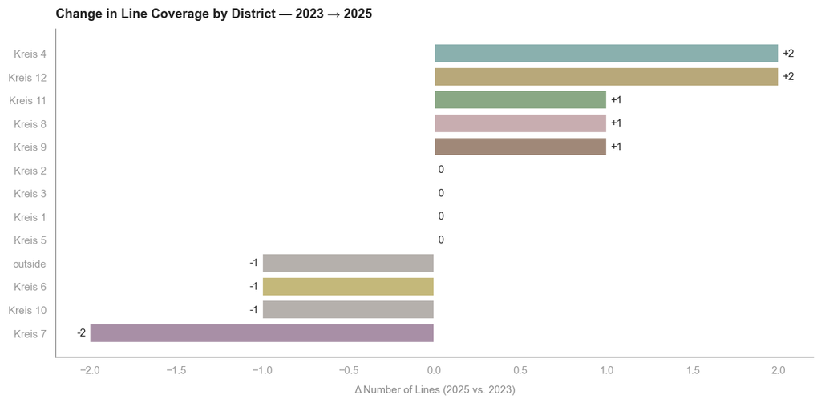

|  | district_name | lines_j23 | lines_j25 | delta |
| --- | --- | --- | --- | --- |
| 0 | Kreis 12 | 5 | 7 | 2 |
| 1 | Kreis 4 | 11 | 13 | 2 |
| 2 | Kreis 11 | 10 | 11 | 1 |
| 3 | Kreis 8 | 6 | 7 | 1 |
| 4 | Kreis 9 | 8 | 9 | 1 |
| 5 | Kreis 5 | 6 | 6 | 0 |
| 6 | Kreis 2 | 12 | 12 | 0 |
| 7 | Kreis 1 | 14 | 14 | 0 |
| 8 | Kreis 3 | 10 | 10 | 0 |
| 9 | Kreis 10 | 4 | 3 | -1 |
| 10 | Kreis 6 | 14 | 13 | -1 |
| 11 | outside | 6 | 5 | -1 |
| 12 | Kreis 7 | 11 | 9 | -2 |

[output not shown]

```python
section_header("Versorgungsqualität nach Stadtkreis")

an.plot_service_quality_by_district(lf_all, cfg)

show_df(an.table_service_quality_by_district(lf_all))

an.plot_service_quality_district_map(lf_all)
```

**Beobachtung:** Der Chart zeigt die Veränderung der Linien-Anbindung pro Stadtkreis (Δ Anzahl verschiedener Linien, 2025 vs. 2023).

**Δ Linien pro Stadtkreis (j23 → j25):**

| Stadtkreis | j23 | j25 | Δ |
| --- | --- | --- | --- |
| Kreis 12 | 5 | 7 | **+2** |
| Kreis 4 | 11 | 13 | **+2** |
| Kreis 9 | 8 | 9 | +1 |
| Kreis 11 | 10 | 11 | +1 |
| Kreis 8 | 6 | 7 | +1 |
| Kreise 1, 2, 3, 5 | — | — | 0 |
| Kreis 10 | 4 | 3 | −1 |
| Kreis 6 | 14 | 13 | −1 |
| Kreis 7 | 11 | 9 | **−2** |

**Wichtiger Kontrast zu Stadtkreis-Chart oben:** Kreis 1 erhielt die meisten neuen Haltestellen (12), aber **null neue Linien** — die Innenstadt wird von denselben Linien bedient, die nun mehr Halte haben. Echte Anbindungs-Verbesserungen (neue Linien) liegen vor allem in Kreis 12 und Kreis 4.

**Verlierer:** Kreis 7 verliert 2 Linien (11→9). Kreis 6 und Kreis 10 verlieren je 1 Linie. Die Versorgungsqualität dieser Kreise hat sich im Betrachtungszeitraum verschlechtert.

## Liniencharakter-Profil — Strukturelle Kennzahlen im Vergleich

Jede Linie hat ein unverwechselbares strukturelles Profil. Fünf Dimensionen im Überblick:

| Dimension | Was sie zeigt |
| --- | --- |
| **Ø Halte / Fahrt** | Routenlänge — je länger, desto mehr Accumulation-Potenzial |
| **Stadtkreise (Anzahl)** | Geografische Reichweite — wie viele verschiedene Kreise werden durchfahren? |
| **Innenstadt-Anteil (%)** | Anteil Halte in Kreisen 1–5 — Exposition zur Innenstadtbelastung |
| **Strukturfaktor (s/Fahrt)** | Ø delay_delta × avg_stops — kumulierter Delay-Aufbau pro Fahrt |
| **Ø Arrival Delay (s)** | Sichtbares Ergebnis für Fahrgäste am Ende |

Heatmap: **Farbe normalisiert pro Spalte** — Dunkel = hoher Wert · Hell = niedriger Wert · Linienbeschriftung in VBZ-Farben.

```
Tram Line Metrics — 5 dimensions per line:
  avg_stops           — avg stops per trip (route length)
  n_districts         — districts served (geographic reach)
  pct_city_center     — share of stops in districts 1–5 (city centre exposure)
  structural_per_trip — avg (departure_delay − arrival_delay) × avg_stops (cumulative build-up)
  mean_arr            — avg arrival delay (passenger-visible outcome)
Color normalized per column — dark = high value · sorted by structural factor.
```

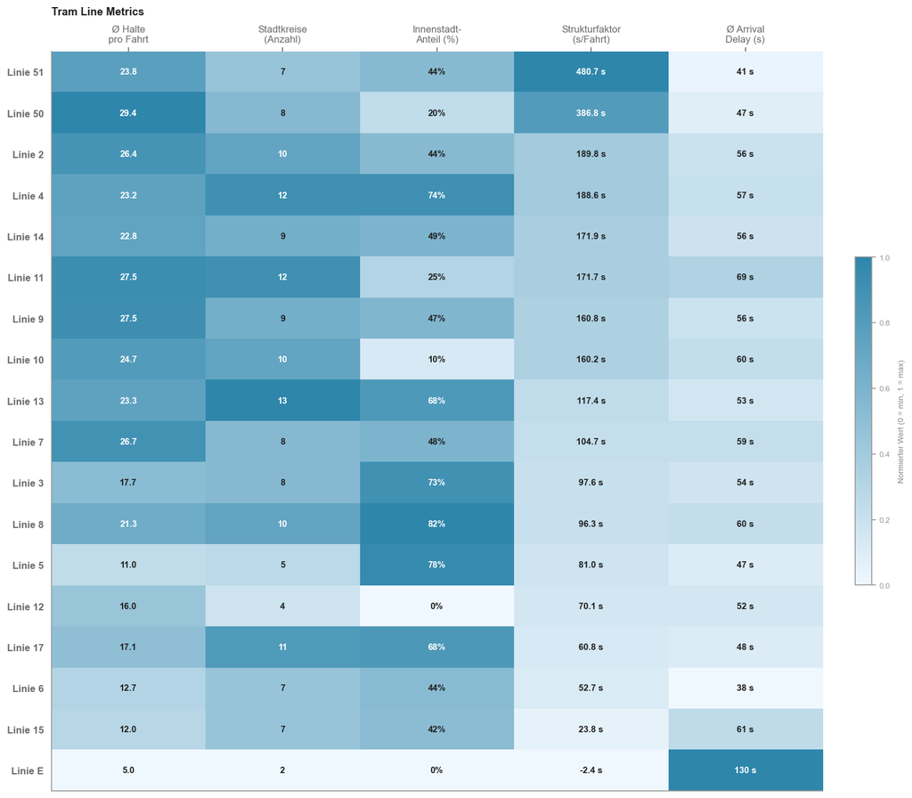

```python
an.plot_line_profiles(lf_all)
```

## Fazit & Rückschluss auf die weitere Analyse

### Was die Netzanalyse für alle weiteren Notebooks bedeutet

Die GTFS-Analyse über 2023, 2024 und 2025 ergibt folgende strukturelle Erkenntnisse:

#### Verändertes Teilnetz — Jahresvergleich mit Vorbehalt

| Linie | j23 | j24 | j25 | Kontext |
| --- | --- | --- | --- | --- |
| **9** | 24 Halte | 32 Halte | 32 Halte | +8 neue Abschnitte ab Dez 2023 |
| **11** | 20 Halte | 33 Halte | 34 Halte | +13 neue Abschnitte ab Dez 2023 |
| **13** | 11 Halte | 30 Halte | 30 Halte | +19 Halte (+173%) ab Dez 2023 |

Für diese Linien ist Linie 9 in 2023 strukturell eine **andere** Linie als Linie 9 in 2024–2025.

> **⚠️ Externe Recherche-Korrektur (Perplexity, Mai 2026):** Die VBZ-Medienmitteilung zum Fahrplanwechsel Dez 2023 nennt **keine formalen Streckenumbauten** für Tramlinien 9, 11, 13 — die ausgewiesenen Änderungen betrafen primär Buslinien. Die GTFS-Unterschiede könnten daher sein:
> - **Flexity-Rollout**: neue Fahrzeuge auf Linien 11/13 → präzisere Haltestellenaufzeichnung im GTFS
> - **Takt-/Umlaufänderungen**: mehr Kurse, andere Wendeäste → neue Stop-IDs im GTFS
> - **GTFS-Modellierungsartefakt**: Fahrplankopplungen die als neue Halte erscheinen

> Das bedeutet: Die "+173%" bei Linie 13 sind real im GTFS-Datensatz sichtbar, aber die Ursache ist unklar. Das `gtfs_year`-Feature ist trotzdem valide — es kodiert einen echten Zeitschnitt. Ob es Netzstruktur oder nur einen Zeiteffekt erfasst, zeigt der Modellvergleich.

#### Stabiles Referenznetz

Linien mit identischer Stoppanzahl j23 = j24 = j25: **L10, L12, L14, L17** — diese können jahresübergreifend direkt verglichen werden ohne Strukturbruch.

#### Das `gtfs_year`-Feature — kritische Bewertung

```
# In 02_preparation.ipynb hinzufügen:
pl.when(pl.col("operating_date") < pl.lit("2024-01-01").str.to_date())
  .then(pl.lit("j23"))
  .otherwise(pl.lit("j24_j25"))
  .alias("gtfs_year")
```

**Was es codiert:** Den Zeitschnitt Dez 2023 — für Linien 9, 11, 13 gibt es im GTFS einen markanten Unterschied. Ob das eine echte Streckenänderung oder ein Modellierungsartefakt ist, ist offen.

**Limitierung:** Für strukturell stabile Linien ist `gtfs_year` eine reine Zeitvariable ohne Netz-Kontext. Ob es tatsächlich die Modellleistung verbessert, **muss empirisch getestet werden**.

**Alternative:** `n_stops_line` als kontinuierliches Signal — trifft den gleichen Sachverhalt, ohne die binäre Vereinfachung.

**Entscheidung:** Feature als Kandidat aufnehmen, im Modellvergleich evaluieren.

#### Hinweis für alle Analysis-Notebooks

> Alle Analysen in `03_analysis_4-spatial`, `03_analysis_3-temporal`, `03_analysis_5-meteo` und `03_analysis_6-events` sollten bei Linien-bezogenen Befunden den Netzwechsel Dezember 2023 als Kontextinformation nennen. Detaillierte Aufschlüsselung immer mit Verweis auf dieses Notebook: `03_analysis_2-network.ipynb`.

Eine wichtige Folgefrage aus der Target-Analyse: **Wenn ein Trip mit Verspätung endet — startet der nächste Trip (selbes Fahrzeug, andere Richtung) dann ebenfalls zu spät?**

> **Wie die Analyse funktioniert:** VBZ plant an den Endpunkten Wendezeit ein (typisch 5–10 Min). Bei moderaten Verspätungen wird diese Wendezeit aufgebraucht und der nächste Trip startet pünktlich. Bei Extremverspätungen (> Wendezeit) kann die Verspätung auf den nächsten Trip übertragen werden — das ist der Kaskadeneffekt.

> Mit `trip_id` und der Sortierung nach `operating_date` + `stop_sequence` lässt sich für jeden Trip der letzte Stop-Delay extrahieren und mit dem ersten Stop-Delay des Nachfolge-Trips vergleichen.

**Warum das für die Modellierung wichtig ist:** Ein Feature `prev_trip_end_delay` (Verspätung am Ende des vorherigen Trips) wäre ein starkes Vorhersage-Signal — insbesondere in den Abendstunden wenn sich Verspätungen aufschaukeln. Das könnte den 21h-Peak aus F-TEMP-01 teilweise erklären.

```
# Skizze für 02_preparation oder Modellierungsphase:
# trip_end_delay = lf.group_by("trip_id").agg(
#     pl.col("arrival_delay").last().alias("trip_end_delay")
# )
# → join mit nächstem Trip über Fahrzeug-ID / Umlauf-ID
```

**Status:** Offen — Daten sind vorhanden (`trip_id` im Master-Set), Implementierung ausstehend. → F-NET-07

## Key Findings

→ Vollständige Findings-Tabelle mit Impact und Action in `03_analysis_0-overview.ipynb`.

[output not shown]